# Applied Statistical Methods - Notebook 3

Peter von Rohr

2021-03-15

## Problem 1: Fixed Linear Effects Model

We want to analyse a dataset with genetic information using a fixed linear effects model. The dataset is taken from the course notes and is shown in Table @ref(tab:datatable).

We assume that the SNP loci have a purely additive effect on the trait. That means for a SNP locus $L$ the absolute value of the genotypic value of the homozygous genotypes ($L_1L_1$ and $L_2L_2$) is taken to be $a_L$ and the genotypic value of the heterozygous genotype ($L_1L_2$) is taken to be $0$. The fixed linear effects model contains the observation in Table @ref(tab:datatable) as the response variable, an intercept and the genotypic values of the the genotypes at the two SNP Loci $G$ and $H$ as predictor variables.

For the observation $y_i$ of animal $i$, we can specify the model as

$$y_i = \beta_0 + W_i \cdot a + \epsilon_i$$

where $\beta_0$ is the intercept, $a$ is the vector of additive SNP-effects, $W_i$ is a row vector denoting the SNP-Genotypes and $\epsilon_i$ is the random error term.

The data can be read from https://charlotte-ngs.github.io/gelasmss2021/data/ex03p01_data.csv. The address from where the data can be downloaded is assigned to a variable.

```r
### # specify path to data file depending on online status
s_data_file <- "https://charlotte-ngs.github.io/gelasmss2021/data/ex03p01_data.csv"
```

It can be read using the following statement

```r
### # read the data into a tibble
tbl_geno_data <- readr::read_csv(file = s_data_file)
```

Genotypic Data Used for Fitting a Fixed Linear Effect Model

| Animal | SNP G | SNP H | Observation |
| --- | --- | --- | --- |
| 1 | 1 | 0 | 510 |
| 2 | 0 | 1 | 528 |
| 3 | 0 | 1 | 505 |
| 4 | 1 | -1 | 539 |
| 5 | 1 | 1 | 530 |
| 6 | 0 | 0 | 489 |
| 7 | 0 | -1 | 486 |
| 8 | -1 | 1 | 485 |
| 9 | 0 | -1 | 478 |
| 10 | -1 | 0 | 479 |
| 11 | 1 | 0 | 520 |
| 12 | 1 | 1 | 521 |
| 13 | -1 | 0 | 473 |
| 14 | -1 | 0 | 457 |
| 15 | 0 | 1 | 497 |
| 16 | 0 | 0 | 516 |
| 17 | 1 | 0 | 524 |
| 18 | 1 | 0 | 502 |
| 19 | 1 | -1 | 508 |
| 20 | 0 | 0 | 506 |

### Your Tasks

- Specify the fixed linear effects model in matrix-vector notation by putting the information from the dataset into the model. Use the same parametrization as shown in the course notes where the intercept $\beta_0$ and the vector $a$ are combined into a single parameter vector $b$. The design matrix that links elements in $b$ to observations $y$ is then called $X$.
- Use the function `Matrix::rankMatrix()` from the `Matrix` package on the matrix $X$ to find out the rank of the design matrix.
- Depending on the rank of $X$ compute an estimate for $b$, if the rank of the matrix is equal to the number of columns of matrix $X$, then the same forumla as was used in the regression model can be used
- Verify your results using the `lm()` function

### Hints

- Read the data using the function `readr::read_csv()`

### Your Solution

Start your solution by reading the data. Then specify the design matrix $X$

```r
# read data with readr::read_csv

# specify the matrix X

# compute the solution for the intercept and the a-values
```

## Problem 2: Genomic Relationship Matrix

From the given dataset that can be obtained from

https://charlotte-ngs.github.io/gelasmss2021/data/ex03p02_data.csv,

compute the genomic relationship matrix $G$. The dataset is organised such that animals are in rows and SNPs are in columns.

### Hints

- Read the data using the function `readr::read_csv()`
- Convert the input data with the function `as.matrix()` to a matrix
- Use the function `apply(mat, 2, mean)` to compute the columnwise mean of matrix `mat`
- Use the `matrix` function to construct the matrix $P$ from the vector of SNP allele frequencies

### Your Solution

Start your solution by reading the data

```r
# read the data using readr::read_csv

# convert intput data to a matrix

# compute the mean across columns

# compute the matrix P
```

## Additional Problem

Write a function in R that accepts a matrix of genotypes and that computes the genomic relationship matrix. Verify your results from Problem 2.

### Hints

- A function in R can be declared using the keyword `function`
- A function in R consists of three parts
  1. the name of the function
  2. the function arguments and
  3. the body of the function.

The following figure shows the general structure of an R-function

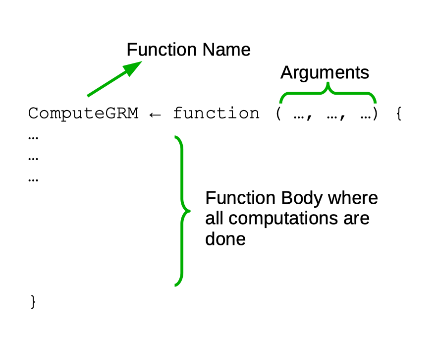

### Your Solution

Start your solution by reading the data

```r
# read the data using readr::read_csv

# convert intput data to a matrix

# compute the mean across columns

# compute the matrix P
```